# Text Analysis for Detective Stories

Yun-Hsiang (Ray) Chan

# I. Introduction

In the EDA section, we have already conducted a complete investigation on the components of detective stories from readers’ annotations. However, there isn’t much interesting insight show up in the EDA section.

Instead of further proving the obvious conclusions from EDA part, we decide to analyze these stories from the text side, try to dig into text features of detective stories and see whether there’s any interesting fact.

One of the research questions our collaborators want to know is the evolution of detective stories. Our statistical analysis will focus on this part, try to see whether there’s any special features from text between detective stories from different decades or years.

If there’s nothing that can distinguish stories between decades, then we might want to see what is the key components differentiating the text features from different stories.

To do the text analysis, we will introduce the idea of **tf-idf score** for each word in text as the text feature of each document. Then we will implement the **K-means clustering algorithm** to fit these features and assign clusters for different stories. Lastly, we will try to investigate the implicit feature that determine the clustering result.

## Explanation of doing an unconventional analysis

The main component of this analysis relies on the idea of text analysis and the choices of method to conduct the analysis (tf-idf, clustering, dimensionality reduction for visualization, and so on).

These methods (e.g. clustering) include some statistical component, while it’s not the traditional testing or modeling expected in a general statistical analysis. This is mainly because of the characteristic of text data that I want to analyze.

I choose this topic as a challenge of learning new things and conduct insightful analysis from the text of detective stories, rather than the annotated dataset. I hope this won’t be criticized and influence the grade of this report.

# II. Assign clusters for detective stories and Preliminary Investigation

In this section, our goal is to assign clusters to detective stories based on their content. There are 3 main steps:

1. Use tf-idf scores for each word (excluding some rare and common words) as the representation vector for each detective story.
2. Implement K-means clustering algorithm for assigning the clusters.
3. Plot out the clustering result in a low-dimensional space, as a preliminary of next step.

## 2.1 Introduction to the idea of tf-idf

The tf-idf score, short for **term frequency-inverse document frequency**, is a numerical statistic that is intended to reflect how important a word is to a document in a collection of corpus. It’s often used as a weighting factor in searches of information retrieval, text mining, and user modeling.

The tf–idf value increases proportionally to the number of times a word appears in the document and is offset by the number of documents in the corpus that contain the word, which helps to adjust for the fact that some words appear more frequently in general.

The intuition behind this formula is that, if a term occurs less frequently among all documents while occurring many times in this specific document, it indicates that this term is valuable to this document.

(Reference: https://en.wikipedia.org/wiki/Tf%E2%80%93idf)

## 2.2 tf-idf scores as representation vector

After introducing the idea of tf-idf, it’s time to introduce how can we use them as a representation vector. For each document, we are able to calculate the tf-idf score for every word in the document. Therefore, we can use these scores to form a vector, as a representation of text feature for this document. This method is popular in information retrieval and text analysis.

To eliminate the negative influence of some rare words or common words, we set the threshold for adding the word to the representation vector. If a word appears in more than 50% of the documents or less than 80% of the documents, then the tf-idf score for this word in every document will be included in the representation vector. Otherwise, the tf-idf score for this word won’t be included.

The reason to set threshold is to reduce the noise of common word that ‘he’ or ‘she’, and reduce the noise of rare terms that might appear only in a specific type of stories (e.g. Holmes). The 50% and 80% are picked based on empirical experience.

**We hope that by reducing the noise, the vector can capture the pattern of commonly occurred verb or noun so that we can detect the topic or writing habits of a particular era.**

At the end, we have a vector with 425 dimensions for each detective story, with each dimension represent the tf-idf of the term, and each term should appear in more than 50% of documents, or less than 80% of documents.

## 2.3 K-means clustering and Dimensionality reduction by MDS.

As we have the representation vector for each stories, it’s time to assign clusters for each story based on these vectors.

The reason we do this step is to figure out why some stories will be assigned to a specific cluster in the next part. Is it because of the publication year? Or it is due to authors, topics, or something we never notice before.

We implement K-means clustering to assign the cluster and draw the plots by:  
1. Prepare the tf-idf matrix, where each row represents a detective story, and each column represent the tf-idf score for a unique word.  
2. Calculate the distance between each row vectors by cosine similarity and form a matrix.  
3. Choose the number of clusters, and apply the K-means algorithm on both tf-idf matrix and distance matrix.  
4. Reduce the dimension of distance similarity to 2 by Multidimensional scaling (MDS). This is a technique to visualize the level of similarity between vectors.  
5. Draw the plots with publication year and author code as a preliminary insight.

To briefly introduce the methods:

- K-means clustering is a method of vector quantization, that aims to partition n observations into k clusters, wehre each observation belongs to the cluster with the nearest mean.
- MDS is a means of visualizing the level of similarity of individual cases of a dataset. It’s used to translate “information about the pairwise distances among a set of n objects” into a configuration of n points mapped into an abstract Cartesian space (2-dimensional space).

(Reference: https://en.wikipedia.org/wiki/K-means_clustering, https://en.wikipedia.org/wiki/Multidimensional_scaling)

Note:

- The clustering result will be mostly the same while slightly different when applying k-means clustering on tf-idf and distance matrices. We believe both type of matrix can capture some special patterns that the other one can’t capture. This is why we choose to do clustering on both matrices.
- In terms of choosing clustering method, we also try both hierarchical clustering and K-means clustering. Both methods will produce similar clustering result for distance matrix, while the hierarchical clustering produces a inconsistent result for tf-idf matrix. Therefore, we believe K-means is more suitable in this case.

**Why clustering:**  
The reason to do clustering is to differentiate the stories by text feature vectors so that we can find out the reason behind cluster. Clustering is one the most popular unsupervised methods for pattern recognition. This is the reason for choosing it.

## 2.4 EDA

In these plots, each point represents one story, and the color represents the cluster.

We first look at the clustering plot by distance matrix and tf-idf matrix with author code information.

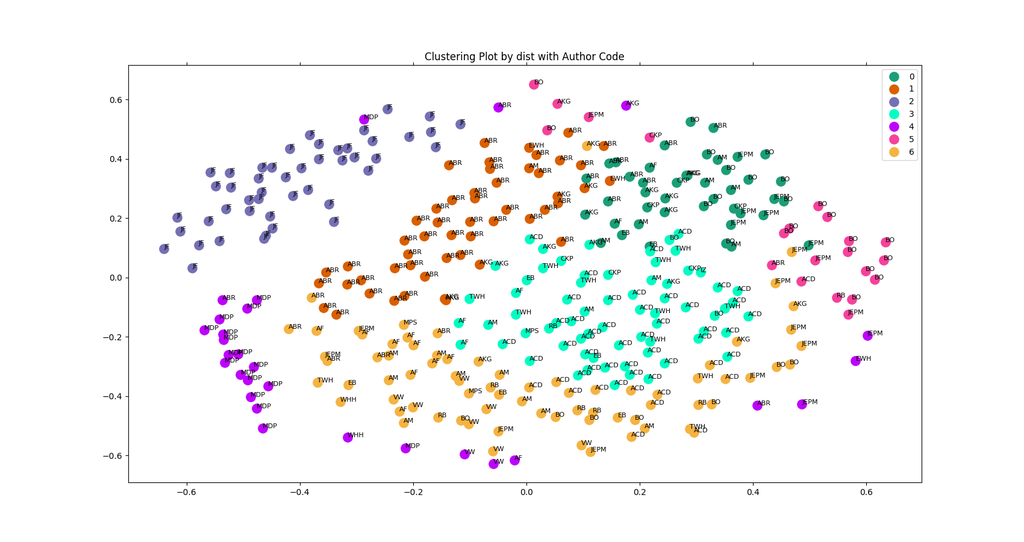

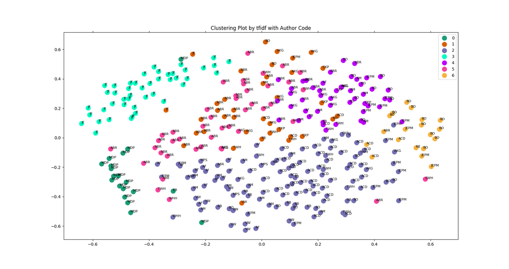

From these two plots, we can know that although we really hope that the clustering of stories can rely on different eras, **it’s more obvious that stories from the same author are more likely to be assigned to one cluster.**

For example, the stories from JF (Jacques Furtelle) are likely to be assigned to one cluster (cluster 2 in plot 1 and cluster 3 in plot 2). It’s reasonable that they are classified in one cluster when the writing habits of the author is unique. Moreover, the topics of these stories are similar (most of them are from the series of detective stories, thinking machine).

Other clusters based on authors are stories from ABR (Arthur B. Reeve) or MDP (Melville Davisson Post) by distance matrix clustering.